# Week 11, Day 5

```r
library(tidyverse)
library(janitor)
library(GGally)
library(modelr)
library(broom)
library(pROC)
library(caret)
```

# MVP

```r
juice <- read_csv("data/orange_juice.csv") %>% clean_names()
```

```r
glimpse(juice)
```

```
Rows: 1,070
Columns: 18
$ purchase        <chr> "CH", "CH", "CH", "MM", "CH", "CH", "CH", "CH", "CH", "CH", "CH", "CH", "CH", "CH…
$ weekof_purchase <dbl> 237, 239, 245, 227, 228, 230, 232, 234, 235, 238, 240, 263, 276, 268, 278, 278, 2…
$ store_id        <dbl> 1, 1, 1, 1, 7, 7, 7, 7, 7, 7, 7, 7, 7, 7, 7, 7, 1, 2, 2, 7, 7, 1, 7, 7, 7, 7, 7, …
$ price_ch        <dbl> 1.75, 1.75, 1.86, 1.69, 1.69, 1.69, 1.69, 1.75, 1.75, 1.75, 1.86, 1.86, 1.99, 1.8…
$ price_mm        <dbl> 1.99, 1.99, 2.09, 1.69, 1.69, 1.99, 1.99, 1.99, 1.99, 1.99, 2.09, 2.13, 2.13, 2.1…
$ disc_ch         <dbl> 0.00, 0.00, 0.17, 0.00, 0.00, 0.00, 0.00, 0.00, 0.00, 0.00, 0.00, 0.27, 0.00, 0.0…
$ disc_mm         <dbl> 0.00, 0.30, 0.00, 0.00, 0.00, 0.00, 0.40, 0.40, 0.40, 0.40, 0.00, 0.00, 0.54, 0.0…
$ special_ch      <dbl> 0, 0, 0, 0, 0, 0, 1, 1, 0, 0, 0, 0, 0, 0, 0, 0, 0, 0, 0, 0, 0, 0, 0, 1, 0, 1, 0, …
$ special_mm      <dbl> 0, 1, 0, 0, 0, 1, 1, 0, 0, 0, 0, 0, 1, 0, 0, 0, 1, 1, 0, 0, 0, 0, 0, 0, 0, 0, 0, …
$ loyal_ch        <dbl> 0.500000, 0.600000, 0.680000, 0.400000, 0.956535, 0.965228, 0.972182, 0.977746, 0…
$ sale_price_mm   <dbl> 1.99, 1.69, 2.09, 1.69, 1.69, 1.99, 1.59, 1.59, 1.59, 1.59, 2.09, 2.13, 1.59, 2.1…
$ sale_price_ch   <dbl> 1.75, 1.75, 1.69, 1.69, 1.69, 1.69, 1.69, 1.75, 1.75, 1.75, 1.86, 1.59, 1.99, 1.8…
$ price_diff      <dbl> 0.24, -0.06, 0.40, 0.00, 0.00, 0.30, -0.10, -0.16, -0.16, -0.16, 0.23, 0.54, -0.4…
$ store7          <chr> "No", "No", "No", "No", "Yes", "Yes", "Yes", "Yes", "Yes", "Yes", "Yes", "Yes", "…
$ pct_disc_mm     <dbl> 0.000000, 0.150754, 0.000000, 0.000000, 0.000000, 0.000000, 0.201005, 0.201005, 0…
$ pct_disc_ch     <dbl> 0.000000, 0.000000, 0.091398, 0.000000, 0.000000, 0.000000, 0.000000, 0.000000, 0…
$ list_price_diff <dbl> 0.24, 0.24, 0.23, 0.00, 0.00, 0.30, 0.30, 0.24, 0.24, 0.24, 0.23, 0.27, 0.14, 0.2…
$ store           <dbl> 1, 1, 1, 1, 0, 0, 0, 0, 0, 0, 0, 0, 0, 0, 0, 0, 1, 2, 2, 0, 0, 1, 0, 0, 0, 0, 0, …
```

```r
summary(juice)
```

```
   purchase         weekof_purchase    store_id       price_ch        price_mm        disc_ch
 Length:1070        Min.   :227.0   Min.   :1.00   Min.   :1.690   Min.   :1.690   Min.   :0.00000
 Class :character   1st Qu.:240.0   1st Qu.:2.00   1st Qu.:1.790   1st Qu.:1.990   1st Qu.:0.00000
 Mode  :character   Median :257.0   Median :3.00   Median :1.860   Median :2.090   Median :0.00000
                    Mean   :254.4   Mean   :3.96   Mean   :1.867   Mean   :2.085   Mean   :0.05186
                    3rd Qu.:268.0   3rd Qu.:7.00   3rd Qu.:1.990   3rd Qu.:2.180   3rd Qu.:0.00000
                    Max.   :278.0   Max.   :7.00   Max.   :2.090   Max.   :2.290   Max.   :0.50000
    disc_mm         special_ch       special_mm        loyal_ch        sale_price_mm   sale_price_ch
 Min.   :0.0000   Min.   :0.0000   Min.   :0.0000   Min.   :0.000011   Min.   :1.190   Min.   :1.390
 1st Qu.:0.0000   1st Qu.:0.0000   1st Qu.:0.0000   1st Qu.:0.325257   1st Qu.:1.690   1st Qu.:1.750
 Median :0.0000   Median :0.0000   Median :0.0000   Median :0.600000   Median :2.090   Median :1.860
 Mean   :0.1234   Mean   :0.1477   Mean   :0.1617   Mean   :0.565782   Mean   :1.962   Mean   :1.816
 3rd Qu.:0.2300   3rd Qu.:0.0000   3rd Qu.:0.0000   3rd Qu.:0.850873   3rd Qu.:2.130   3rd Qu.:1.890
 Max.   :0.8000   Max.   :1.0000   Max.   :1.0000   Max.   :0.999947   Max.   :2.290   Max.   :2.090
   price_diff         store7           pct_disc_mm      pct_disc_ch      list_price_diff     store
 Min.   :-0.6700   Length:1070        Min.   :0.0000   Min.   :0.00000   Min.   :0.000   Min.   :0.000
 1st Qu.: 0.0000   Class :character   1st Qu.:0.0000   1st Qu.:0.00000   1st Qu.:0.140   1st Qu.:0.000
 Median : 0.2300   Mode  :character   Median :0.0000   Median :0.00000   Median :0.240   Median :2.000
 Mean   : 0.1465                      Mean   :0.0593   Mean   :0.02731   Mean   :0.218   Mean   :1.631
 3rd Qu.: 0.3200                      3rd Qu.:0.1127   3rd Qu.:0.00000   3rd Qu.:0.300   3rd Qu.:3.000
 Max.   : 0.6400                      Max.   :0.4020   Max.   :0.25269   Max.   :0.440   Max.   :4.000
```

## Data Preperation

### 1. Replace `purchase` with logical `purchase_mm`

```r
juice_clean <- juice %>%
  mutate(purchase_mm = if_else(purchase == "MM", TRUE, FALSE), .after = "purchase")

juice_clean <- juice_clean %>%
  mutate(purchase_mm = as.factor(purchase_mm)) %>%
  select(-purchase)
```

### 2. Update `store_id`, `special_ch`, `special_mm`, `store7` & `store` To Factors

```r
juice_clean <- juice_clean %>%
  mutate(store_id = as.factor(store_id),
         special_ch = as.factor(special_ch),
         special_mm = as.factor(special_mm),
         store7 = as.factor(store7),
         store = as.factor(store))
```

### 3. Decide On Management of `weekof_purchase` Variable

For this task, I am going to assume that week of purchase would correlate in some way to time periods where discounts where offered on either brand. I will also assume that it is the discount that is the predicting factor, not the week.

As data on data on discounts at the time of purchase is available through other variables, for now, I will remove the `weekof_purchase` variable.

```r
juice_clean <- juice_clean %>%
  select(-weekof_purchase)
```

### 4. Wrangle `store_id`, `store7` & `store` Variables.

Based on the counts `store` and `store_id` the only difference is that `store` lists a store 0 with 356 observations and `store_id` lists a store 7 with 356 observations. These therefor look to be the same store. As there is an additonal `store7` variable, I will assume that 7 is the correct variable and drop the `store` and `store7` variables.

```r
juice %>%
  count(store)
```

| store | n |
| --- | --- |
| 0 | 356 |
| 1 | 157 |
| 2 | 222 |
| 3 | 196 |
| 4 | 139 |

```r
juice %>%
  count(store_id)
```

| store_id | n |
| --- | --- |
| 1 | 157 |
| 2 | 222 |
| 3 | 196 |
| 4 | 139 |
| 7 | 356 |

```r
juice_clean <- juice_clean %>%
  select(-c(store, store7))
```

### 5. Check for Aliases Variables

```r
juice_clean <- juice_clean %>%
  select(-c(sale_price_mm, sale_price_ch, -price_diff, -list_price_diff))
```

```r
alias(purchase_mm ~ ., data = juice_clean)
```

```
Model :
purchase_mm ~ store_id + price_ch + price_mm + disc_ch + disc_mm +
    special_ch + special_mm + loyal_ch + price_diff + pct_disc_mm +
    pct_disc_ch + list_price_diff

Complete :
                (Intercept) store_id2 store_id3 store_id4 store_id7 price_ch price_mm disc_ch disc_mm
price_diff       0           0         0         0         0        -1        1        1      -1
list_price_diff  0           0         0         0         0        -1        1        0       0
                special_ch1 special_mm1 loyal_ch pct_disc_mm pct_disc_ch
price_diff       0           0           0        0           0
list_price_diff  0           0           0        0           0
```

### 6. Check for Strongly Correlated Potential Predictors

There are still a significant number of variables that relate to price.

- `price_ch`
- `price_mm`
- `disc_ch`
- `disc_mm`
- `special_ch`
- `special_mm`
- `price_diff`
- `pct_disc_mm`
- `pct_disc_ch`
- `list_price_diff`

Having checked to see if any of these are strongly correlated to one another and whether any should be dropped:

- `pct_disc_mm` and `disc_mm` have a very strong positive correlation of 0.999 which is statistically significant.
- `pct_disc_ch` and `disc_ch` have a very strong positive correlation of 0.999 which is statistically significant.

This is to be expected and for the purposes of this exercise I will drop `pct_disc_mm` and `pct_disc_ch`.

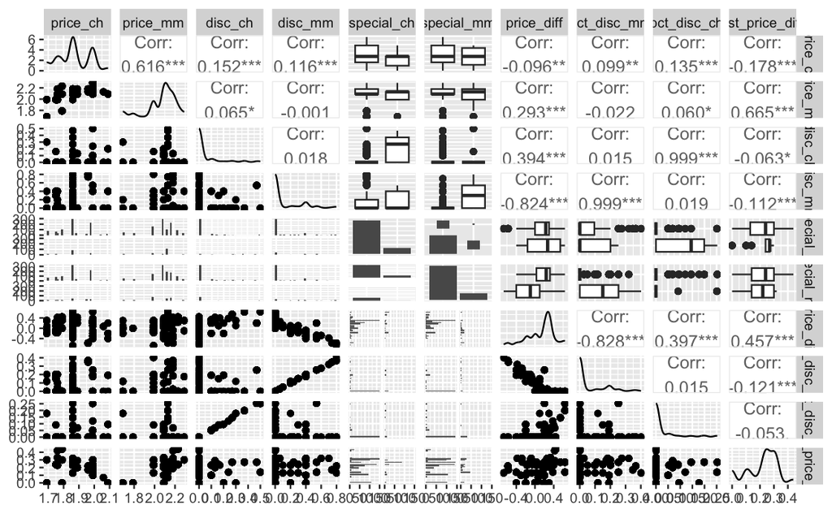

```r
juice_clean %>%
  select(-c(purchase_mm, store_id, loyal_ch)) %>%
  ggpairs(progress = FALSE)
```

```r
juice_clean <- juice_clean %>%
  select(-c(pct_disc_mm, pct_disc_ch))
```

## Explore Potential Predictors

To make it easier to initially explore potential predictor candidates, I have separated the variables into 3 groups.

Group 1 / Price: `price_ch`, `price_mm`, `disc_ch`, `disc_mm`, `special_ch`, `special_mm`, `price_diff`, `list_price_diff` Group 2 / Store: `store_id` Group 3 / Customer Attributes: `loyal_ch`

### 1. Explore Group 1

The below look like the most promising potential predictors.

- `disc_ch`
- `disc_mm`
- `price_diff`
- `list_price_diff`

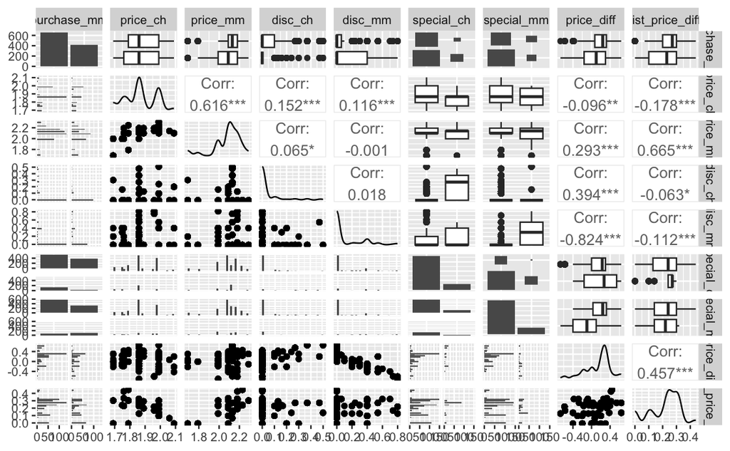

```r
juice_clean %>%
  select(-c(store_id, loyal_ch)) %>%
  ggpairs(progress = FALSE)
```

### 2. Explore Group 2

There does also appear to be some correlation with `store_id`.

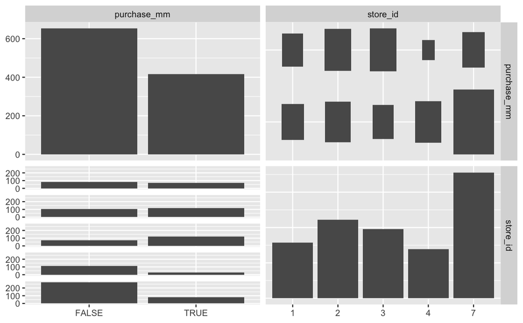

```r
juice_clean %>%
  select(purchase_mm, store_id) %>%
  ggpairs(progress = FALSE)
```

### 3. Explore Group 3

There does also appear to be some correlation with `loyal_ch`.

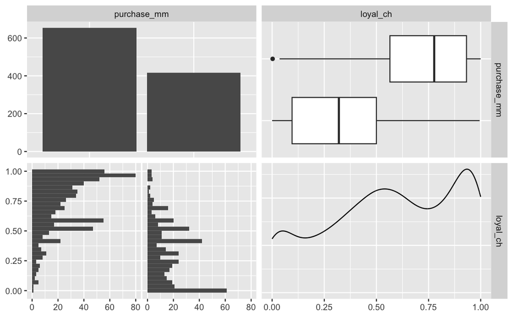

```r
juice_clean %>%
  select(purchase_mm, loyal_ch) %>%
  ggpairs(progress = FALSE)
```

## Check Predictors for Statistical Significance

### `disc_ch`

`disc_ch` appears to be a statistically significant predictor.

```r
# From Group 1 / `disc_ch` as predictor

juice_discch_model <- glm(
  purchase_mm ~ disc_ch,
  data = juice_clean,
  family = binomial(link = "logit")
)

summary(juice_discch_model)
```

```
Call:
glm(formula = purchase_mm ~ disc_ch, family = binomial(link = "logit"),
    data = juice_clean)

Deviance Residuals:
    Min       1Q   Median       3Q      Max
-1.0622  -1.0622  -0.8634   1.2971   2.1756

Coefficients:
            Estimate Std. Error z value Pr(>|z|)
(Intercept)  -0.2771     0.0680  -4.075 4.60e-05 ***
disc_ch      -3.9819     0.7148  -5.571 2.54e-08 ***
---
Signif. codes:  0 ‘***’ 0.001 ‘**’ 0.01 ‘*’ 0.05 ‘.’ 0.1 ‘ ’ 1

(Dispersion parameter for binomial family taken to be 1)

    Null deviance: 1430.9  on 1069  degrees of freedom
Residual deviance: 1390.9  on 1068  degrees of freedom
AIC: 1394.9

Number of Fisher Scoring iterations: 4
```

### `disc_mm`

`disc_mm` appears to be a statistically significant predictor.

```r
# From Group 1 / `disc_mm` as predictor

juice_discmm_model <- glm(
  purchase_mm ~ disc_mm,
  data = juice_clean,
  family = binomial(link = "logit")
)

summary(juice_discmm_model)
```

```
Call:
glm(formula = purchase_mm ~ disc_mm, family = binomial(link = "logit"),
    data = juice_clean)

Deviance Residuals:
    Min       1Q   Median       3Q      Max
-1.4443  -0.9164  -0.9164   1.3229   1.4631

Coefficients:
            Estimate Std. Error z value Pr(>|z|)
(Intercept) -0.65038    0.07421  -8.764  < 2e-16 ***
disc_mm      1.57365    0.29415   5.350  8.8e-08 ***
---
Signif. codes:  0 ‘***’ 0.001 ‘**’ 0.01 ‘*’ 0.05 ‘.’ 0.1 ‘ ’ 1

(Dispersion parameter for binomial family taken to be 1)

    Null deviance: 1430.9  on 1069  degrees of freedom
Residual deviance: 1401.6  on 1068  degrees of freedom
AIC: 1405.6

Number of Fisher Scoring iterations: 4
```

### `price_diff`

`price_diff` appears to be a statistically significant predictor.

```r
# From Group 1 / `price_diff` as predictor

juice_pricediff_model <- glm(
  purchase_mm ~ price_diff,
  data = juice_clean,
  family = binomial(link = "logit")
)

summary(juice_pricediff_model)
```

```
Call:
glm(formula = purchase_mm ~ price_diff, family = binomial(link = "logit"),
    data = juice_clean)

Deviance Residuals:
    Min       1Q   Median       3Q      Max
-1.7543  -0.9148  -0.8360   1.2443   1.8641

Coefficients:
            Estimate Std. Error z value Pr(>|z|)
(Intercept) -0.15596    0.07289  -2.140   0.0324 *
price_diff  -2.16873    0.25190  -8.609   <2e-16 ***
---
Signif. codes:  0 ‘***’ 0.001 ‘**’ 0.01 ‘*’ 0.05 ‘.’ 0.1 ‘ ’ 1

(Dispersion parameter for binomial family taken to be 1)

    Null deviance: 1430.9  on 1069  degrees of freedom
Residual deviance: 1348.8  on 1068  degrees of freedom
AIC: 1352.8

Number of Fisher Scoring iterations: 4
```

### `list_price_diff`

`list_price_diff` appears to be a statistically significant predictor.

```r
# From Group 1 / `loyalch` as predictor

juice_listpricediff_model <- glm(
  purchase_mm ~ list_price_diff,
  data = juice_clean,
  family = binomial(link = "logit")
)

summary(juice_listpricediff_model)
```

```
Call:
glm(formula = purchase_mm ~ list_price_diff, family = binomial(link = "logit"),
    data = juice_clean)

Deviance Residuals:
    Min       1Q   Median       3Q      Max
-1.2749  -0.9628  -0.8688   1.2695   1.6914

Coefficients:
                Estimate Std. Error z value Pr(>|z|)
(Intercept)       0.2262     0.1405   1.610    0.107
list_price_diff  -3.1438     0.5911  -5.318 1.05e-07 ***
---
Signif. codes:  0 ‘***’ 0.001 ‘**’ 0.01 ‘*’ 0.05 ‘.’ 0.1 ‘ ’ 1

(Dispersion parameter for binomial family taken to be 1)

    Null deviance: 1430.9  on 1069  degrees of freedom
Residual deviance: 1402.0  on 1068  degrees of freedom
AIC: 1406

Number of Fisher Scoring iterations: 4
```

### `loyal_ch`

`loyal_ch` appears to be a statistically significant predictor.

```r
# From Group 2 / `loyal_ch` as predictor

juice_loyalch_model <- glm(
  purchase_mm ~ loyal_ch,
  data = juice_clean,
  family = binomial(link = "logit")
)

summary(juice_loyalch_model)
```

```
Call:
glm(formula = purchase_mm ~ loyal_ch, family = binomial(link = "logit"),
    data = juice_clean)

Deviance Residuals:
    Min       1Q   Median       3Q      Max
-2.3677  -0.6672  -0.3001   0.6326   2.5863

Coefficients:
            Estimate Std. Error z value Pr(>|z|)
(Intercept)   2.7554     0.1996   13.80   <2e-16 ***
loyal_ch     -6.0948     0.3611  -16.88   <2e-16 ***
---
Signif. codes:  0 ‘***’ 0.001 ‘**’ 0.01 ‘*’ 0.05 ‘.’ 0.1 ‘ ’ 1

(Dispersion parameter for binomial family taken to be 1)

    Null deviance: 1430.85  on 1069  degrees of freedom
Residual deviance:  920.57  on 1068  degrees of freedom
AIC: 924.57

Number of Fisher Scoring iterations: 5
```

### `store_id`

Only some `store_id` values appear to be statistically significant predictors.

```r
# From Group 3 / `store_id` as predictor

juice_storeid_model <- glm(
  purchase_mm ~ store_id,
  data = juice_clean,
  family = binomial(link = "logit")
)

summary(juice_storeid_model)
```

```
Call:
glm(formula = purchase_mm ~ store_id, family = binomial(link = "logit"),
    data = juice_clean)

Deviance Residuals:
    Min       1Q   Median       3Q      Max
-1.3861  -0.7236  -0.7236   1.1469   1.8103

Coefficients:
            Estimate Std. Error z value Pr(>|z|)
(Intercept)  -0.1660     0.1602  -1.036  0.30005
store_id2     0.2381     0.2090   1.139  0.25470
store_id3     0.6443     0.2174   2.964  0.00304 **
store_id4    -1.2567     0.2676  -4.696 2.66e-06 ***
store_id7    -1.0404     0.2037  -5.107 3.27e-07 ***
---
Signif. codes:  0 ‘***’ 0.001 ‘**’ 0.01 ‘*’ 0.05 ‘.’ 0.1 ‘ ’ 1

(Dispersion parameter for binomial family taken to be 1)

    Null deviance: 1430.9  on 1069  degrees of freedom
Residual deviance: 1306.0  on 1065  degrees of freedom
AIC: 1316

Number of Fisher Scoring iterations: 4
```

### Findings

loyal_ch / Statistically Significant / B1 Coefficient -6.0948 disc_ch / Statistically Significant / B1 Coefficient -3.9819 list_price_diff / Statistically Significant / B1 Coefficient -3.1438 price_diff / Statistically Significant / B1 Coefficient -2.16873 disc_mm / Statistically Significant / B1 Coefficient 1.57365 store_id / IDs 3, 4 & 7 Statistically Significant.

## Add Predictions And Calculate AUC For Different Predictor Combinations

I will add predictions in the order of B1 Coefficient size and record AUC values.

### 1x Predictor

```r
juice_model_1_pred <- glm(
  purchase_mm ~ loyal_ch,
  data = juice_clean,
  family = binomial(link = "logit")
)

juice_model_1_summary <- clean_names(tidy(juice_model_1_pred))

juice_model_1_summary
```

| term | estimate | std_error | statistic | p_value |
| --- | --- | --- | --- | --- |
| (Intercept) | 2.755397 | 0.1995901 | 13.80528 | 2.368569e-43 |
| loyal_ch | -6.094763 | 0.3611485 | -16.87606 | 6.750426e-64 |

```r
juice_preds <- juice_clean %>%
  add_predictions(juice_model_1_pred,
                  type = "response")

roc_obj_juice_1_pred <- juice_preds %>%
  roc(response = purchase_mm,
      predictor = pred)
auc(roc_obj_juice_1_pred)
```

```
Area under the curve: 0.874
```

### 2x Predictor

```r
juice_model_2_pred <- glm(
  purchase_mm ~ loyal_ch + disc_ch,
  data = juice_clean,
  family = binomial(link = "logit")
)

juice_model_2_summary <- clean_names(tidy(juice_model_2_pred))

juice_model_2_summary
```

| term | estimate | std_error | statistic | p_value |
| --- | --- | --- | --- | --- |
| (Intercept) | 2.910348 | 0.2081804 | 13.979931 | 2.066870e-44 |
| loyal_ch | -6.100192 | 0.3679073 | -16.580788 | 9.596254e-62 |
| disc_ch | -3.565256 | 0.8481884 | -4.203378 | 2.629610e-05 |

```r
juice_preds <- juice_clean %>%
  add_predictions(juice_model_2_pred,
                  type = "response")

roc_obj_juice_2_pred <- juice_preds %>%
  roc(response = purchase_mm,
      predictor = pred)
auc(roc_obj_juice_2_pred)
```

```
Area under the curve: 0.8808
```

### 3x Predictor

```r
juice_model_3_pred <- glm(
  purchase_mm ~ loyal_ch + disc_ch + list_price_diff,
  data = juice_clean,
  family = binomial(link = "logit")
)

juice_model_3_summary <- clean_names(tidy(juice_model_3_pred))

juice_model_3_summary
```

| term | estimate | std_error | statistic | p_value |
| --- | --- | --- | --- | --- |
| (Intercept) | 3.800553 | 0.2874767 | 13.220390 | 6.691626e-40 |
| loyal_ch | -6.118656 | 0.3722784 | -16.435699 | 1.061928e-60 |
| disc_ch | -4.103931 | 0.9070393 | -4.524535 | 6.052849e-06 |
| list_price_diff | -4.001923 | 0.7939954 | -5.040234 | 4.649624e-07 |

```r
juice_preds <- juice_clean %>%
  add_predictions(juice_model_3_pred,
                  type = "response")

roc_obj_juice_3_pred <- juice_preds %>%
  roc(response = purchase_mm,
      predictor = pred)
auc(roc_obj_juice_3_pred)
```

```
Area under the curve: 0.8895
```

### 4x Predictor

```r
juice_model_4_pred <- glm(
  purchase_mm ~ loyal_ch + disc_ch + list_price_diff + price_diff,
  data = juice_clean,
  family = binomial(link = "logit")
)

juice_model_4_summary <- clean_names(tidy(juice_model_4_pred))

juice_model_4_summary
```

| term | estimate | std_error | statistic | p_value |
| --- | --- | --- | --- | --- |
| (Intercept) | 3.499899 | 0.2888974 | 12.114676 | 8.831225e-34 |
| loyal_ch | -6.359095 | 0.3867916 | -16.440625 | 9.790370e-61 |
| disc_ch | -1.767278 | 0.9504647 | -1.859383 | 6.297284e-02 |
| list_price_diff | -1.160152 | 0.9190175 | -1.262383 | 2.068111e-01 |
| price_diff | -2.427999 | 0.4109245 | -5.908627 | 3.449708e-09 |

```r
juice_preds <- juice_clean %>%
  add_predictions(juice_model_4_pred,
                  type = "response")

roc_obj_juice_4_pred <- juice_preds %>%
  roc(response = purchase_mm,
      predictor = pred)
auc(roc_obj_juice_4_pred)
```

```
Area under the curve: 0.8999
```

### 5x Predictor A

```r
juice_model_5_pred <- glm(
  purchase_mm ~ loyal_ch + disc_ch + list_price_diff + price_diff + disc_mm,
  data = juice_clean,
  family = binomial(link = "logit")
)

juice_model_5_summary <- clean_names(tidy(juice_model_5_pred))

juice_model_5_summary
```

| term | estimate | std_error | statistic | p_value |
| --- | --- | --- | --- | --- |
| (Intercept) | 3.499899 | 0.2888974 | 12.114676 | 8.831225e-34 |
| loyal_ch | -6.359095 | 0.3867916 | -16.440625 | 9.790370e-61 |
| disc_ch | -1.767278 | 0.9504647 | -1.859383 | 6.297284e-02 |
| list_price_diff | -1.160152 | 0.9190175 | -1.262383 | 2.068111e-01 |
| price_diff | -2.427999 | 0.4109245 | -5.908627 | 3.449708e-09 |
| disc_mm | NA | NA | NA | NA |

```r
juice_preds <- juice_clean %>%
  add_predictions(juice_model_5_pred,
                  type = "response")
roc_obj_juice_5_pred <- juice_preds %>%
  roc(response = purchase_mm,
      predictor = pred)
auc(roc_obj_juice_5_pred)
```

```
Area under the curve: 0.8999
```

### 5x Predictor B

```r
juice_model_5_pred_b <- glm(
  purchase_mm ~ loyal_ch + disc_ch + list_price_diff + price_diff + store_id,
  data = juice_clean,
  family = binomial(link = "logit")
)

juice_model_5_summary_b <- clean_names(tidy(juice_model_5_pred_b))

juice_preds <- juice_clean %>%
  add_predictions(juice_model_5_pred_b,
                  type = "response")

roc_obj_juice_5_pred_b <- juice_preds %>%
  roc(response = purchase_mm,
      predictor = pred)
auc(roc_obj_juice_5_pred_b)
```

```
Area under the curve: 0.9022
```

### Findings

We can see from the above results that the below model returns the highest AUC.

purchase_mm ~ loyal_ch + disc_ch + list_price_diff + price_diff + store_id

### Plot ROC Curve for All 6 Models

We can also plot the ROC Curve for all 6 models to visual the above results. From this, we can see that “5b” does indeed appear to be the best option at this stage.

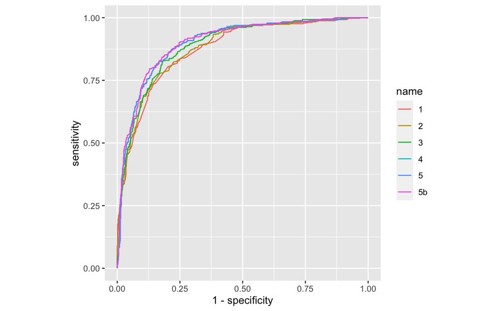

```r
roc_curve <- ggroc(data = list("1" = roc_obj_juice_1_pred,
                               "2" = roc_obj_juice_2_pred,
                               "3" = roc_obj_juice_3_pred,
                               "4" = roc_obj_juice_4_pred,
                               "5" = roc_obj_juice_5_pred,
                               "5b" = roc_obj_juice_5_pred_b),
                   legacy.axes = TRUE)+
  coord_fixed()

roc_curve
```

## Cross Validation

To for over-fit, we will use cross-validation.

### Update TRUE/FALSE To “Yes”/“No” for `purchase_mm`

```r
juice_clean_fct <- juice_clean %>%
  mutate(purchase_mm = if_else(purchase_mm == TRUE, "Yes", "No"),
         purchase_mm = as.factor(purchase_mm))
```

### Set Training Specifications

```r
train_control <-  trainControl(method = "repeatedcv",
                               number = 5,
                               repeats = 100,
                               savePredictions = TRUE,
                               classProbs = TRUE,
                               summaryFunction = twoClassSummary)
```

### Check Validated AUC/ROC Values

```r
juice_model_1_pred_validate <- train(purchase_mm ~ loyal_ch,
               data = juice_clean_fct,
               trControl = train_control,
               method = "glm",
               family = binomial(link = "logit"))
juice_model_1_pred_validate$results$ROC
```

```
[1] 0.8740542
```

```r
juice_model_2_pred_validate <- train(purchase_mm ~ loyal_ch + disc_ch,
               data = juice_clean_fct,
               trControl = train_control,
               method = "glm",
               family = binomial(link = "logit"))
juice_model_2_pred_validate$results$ROC
```

```
[1] 0.880061
```

```r
juice_model_3_pred_validate <- train(purchase_mm ~ loyal_ch + disc_ch + list_price_diff,
               data = juice_clean_fct,
               trControl = train_control,
               method = "glm",
               family = binomial(link = "logit"))
juice_model_3_pred_validate$results$ROC
```

```
[1] 0.8883477
```

```r
juice_model_4_pred_validate <- train(purchase_mm ~ loyal_ch + disc_ch + list_price_diff + price_diff,
               data = juice_clean_fct,
               trControl = train_control,
               method = "glm",
               family = binomial(link = "logit"))
juice_model_4_pred_validate$results$ROC
```

```
[1] 0.89826
```

```r
juice_model_5_pred_validate <- train(purchase_mm ~ loyal_ch + disc_ch + list_price_diff + price_diff + disc_mm,
               data = juice_clean_fct,
               trControl = train_control,
               method = "glm",
               family = binomial(link = "logit"))

juice_model_5_pred_validate$results$ROC
```

[output not shown]

```r
juice_model_5b_pred_validate <- train(purchase_mm ~ loyal_ch + disc_ch + list_price_diff + price_diff + store_id,
               data = juice_clean_fct,
               trControl = train_control,
               method = "glm",
               family = binomial(link = "logit"))
juice_model_5b_pred_validate$results$ROC
```

```
[1] 0.8983787
```

### Results

juice_model_4_pred purchase_mm ~ loyal_ch + disc_ch + list_price_diff + price_diff AUC 0.8999 / Cross Validated AUC 0.8982 AUC Dif. 0.0017

juice_model_5_pred purchase_mm ~ loyal_ch + disc_ch + list_price_diff + price_diff + disc_mm AUC 0.8999 / Cross Validated AUC 0.8984135 AUC Dif. 0.0014865

### Interpretation

- None of the models have a large decrease in AUC following Cross Validation, suggesting that none of the models are over-fit.
- Although the Cross Validated AUC increases as the number of predictors increase, it could be argued that the increases are small. For example, if we were to round the Cross Validated AUC to 2x decimal places then the model with 4 predictors would have the same Cross Validated AUC as the two models wit 5x predictors (0.90).
- With the above in mind, to balance AUC score with simplicity, I would interpret the below model as being the best predictive classifier in this instance:

juice_model_4_pred purchase_mm ~ loyal_ch + disc_ch + list_price_diff + price_diff AUC 0.8999 / Cross Validated AUC 0.8982 AUC Diff. 0.0017